# Risk Factor Analysis

## Outcome Variable

**Outcome Variable:** ever_co

## Predictor Variables

**Intervention Variable:** predexfd6

**Adjustment Set:**

unadjusted

## Stratifying Variables

The analysis was stratified on these variable(s):

- agecat
- studyid
- country

## Data Summary

| agecat | studyid | country | predexfd6 | ever_co | n_cell | n |
| --- | --- | --- | --- | --- | --- | --- |
| 0-24 months | CMC-V-BCS-2002 | INDIA | 1 | 0 | 15 | 19 |
| 0-24 months | CMC-V-BCS-2002 | INDIA | 1 | 1 | 4 | 19 |
| 0-24 months | CMC-V-BCS-2002 | INDIA | 0 | 0 | 0 | 19 |
| 0-24 months | CMC-V-BCS-2002 | INDIA | 0 | 1 | 0 | 19 |
| 0-24 months | EE | PAKISTAN | 1 | 0 | 20 | 48 |
| 0-24 months | EE | PAKISTAN | 1 | 1 | 23 | 48 |
| 0-24 months | EE | PAKISTAN | 0 | 0 | 5 | 48 |
| 0-24 months | EE | PAKISTAN | 0 | 1 | 0 | 48 |
| 0-24 months | GMS-Nepal | NEPAL | 1 | 0 | 279 | 565 |
| 0-24 months | GMS-Nepal | NEPAL | 1 | 1 | 141 | 565 |
| 0-24 months | GMS-Nepal | NEPAL | 0 | 0 | 93 | 565 |
| 0-24 months | GMS-Nepal | NEPAL | 0 | 1 | 52 | 565 |
| 0-24 months | IRC | INDIA | 1 | 0 | 0 | 14 |
| 0-24 months | IRC | INDIA | 1 | 1 | 0 | 14 |
| 0-24 months | IRC | INDIA | 0 | 0 | 12 | 14 |
| 0-24 months | IRC | INDIA | 0 | 1 | 2 | 14 |
| 0-24 months | JiVitA-3 | BANGLADESH | 1 | 0 | 11280 | 15902 |
| 0-24 months | JiVitA-3 | BANGLADESH | 1 | 1 | 1121 | 15902 |
| 0-24 months | JiVitA-3 | BANGLADESH | 0 | 0 | 3166 | 15902 |
| 0-24 months | JiVitA-3 | BANGLADESH | 0 | 1 | 335 | 15902 |
| 0-24 months | JiVitA-4 | BANGLADESH | 1 | 0 | 3154 | 4753 |
| 0-24 months | JiVitA-4 | BANGLADESH | 1 | 1 | 549 | 4753 |
| 0-24 months | JiVitA-4 | BANGLADESH | 0 | 0 | 834 | 4753 |
| 0-24 months | JiVitA-4 | BANGLADESH | 0 | 1 | 216 | 4753 |
| 0-24 months | Keneba | GAMBIA | 1 | 0 | 719 | 2235 |
| 0-24 months | Keneba | GAMBIA | 1 | 1 | 107 | 2235 |
| 0-24 months | Keneba | GAMBIA | 0 | 0 | 1145 | 2235 |
| 0-24 months | Keneba | GAMBIA | 0 | 1 | 264 | 2235 |
| 0-24 months | LCNI-5 | MALAWI | 1 | 0 | 44 | 272 |
| 0-24 months | LCNI-5 | MALAWI | 1 | 1 | 3 | 272 |

[output cut: 186 more lines]

The following strata were considered:

- agecat: 0-24 months, studyid: CMC-V-BCS-2002, country: INDIA
- agecat: 0-24 months, studyid: EE, country: PAKISTAN
- agecat: 0-24 months, studyid: GMS-Nepal, country: NEPAL
- agecat: 0-24 months, studyid: IRC, country: INDIA
- agecat: 0-24 months, studyid: JiVitA-3, country: BANGLADESH
- agecat: 0-24 months, studyid: JiVitA-4, country: BANGLADESH
- agecat: 0-24 months, studyid: Keneba, country: GAMBIA
- agecat: 0-24 months, studyid: LCNI-5, country: MALAWI
- agecat: 0-24 months, studyid: MAL-ED, country: BANGLADESH
- agecat: 0-24 months, studyid: MAL-ED, country: BRAZIL
- agecat: 0-24 months, studyid: MAL-ED, country: INDIA
- agecat: 0-24 months, studyid: MAL-ED, country: NEPAL
- agecat: 0-24 months, studyid: MAL-ED, country: PERU
- agecat: 0-24 months, studyid: MAL-ED, country: SOUTH AFRICA
- agecat: 0-24 months, studyid: MAL-ED, country: TANZANIA, UNITED REPUBLIC OF
- agecat: 0-24 months, studyid: PROVIDE, country: BANGLADESH
- agecat: 0-24 months, studyid: SAS-CompFeed, country: INDIA
- agecat: 0-24 months, studyid: SAS-FoodSuppl, country: INDIA
- agecat: 0-6 months, studyid: CMC-V-BCS-2002, country: INDIA
- agecat: 0-6 months, studyid: EE, country: PAKISTAN
- agecat: 0-6 months, studyid: GMS-Nepal, country: NEPAL
- agecat: 0-6 months, studyid: IRC, country: INDIA
- agecat: 0-6 months, studyid: JiVitA-3, country: BANGLADESH
- agecat: 0-6 months, studyid: JiVitA-4, country: BANGLADESH
- agecat: 0-6 months, studyid: Keneba, country: GAMBIA
- agecat: 0-6 months, studyid: LCNI-5, country: MALAWI
- agecat: 0-6 months, studyid: MAL-ED, country: BANGLADESH
- agecat: 0-6 months, studyid: MAL-ED, country: BRAZIL
- agecat: 0-6 months, studyid: MAL-ED, country: INDIA
- agecat: 0-6 months, studyid: MAL-ED, country: NEPAL
- agecat: 0-6 months, studyid: MAL-ED, country: PERU
- agecat: 0-6 months, studyid: MAL-ED, country: SOUTH AFRICA
- agecat: 0-6 months, studyid: MAL-ED, country: TANZANIA, UNITED REPUBLIC OF
- agecat: 0-6 months, studyid: PROVIDE, country: BANGLADESH
- agecat: 0-6 months, studyid: SAS-CompFeed, country: INDIA
- agecat: 0-6 months, studyid: SAS-FoodSuppl, country: INDIA
- agecat: 6-24 months, studyid: CMC-V-BCS-2002, country: INDIA
- agecat: 6-24 months, studyid: EE, country: PAKISTAN
- agecat: 6-24 months, studyid: GMS-Nepal, country: NEPAL
- agecat: 6-24 months, studyid: IRC, country: INDIA
- agecat: 6-24 months, studyid: JiVitA-3, country: BANGLADESH
- agecat: 6-24 months, studyid: JiVitA-4, country: BANGLADESH
- agecat: 6-24 months, studyid: Keneba, country: GAMBIA
- agecat: 6-24 months, studyid: LCNI-5, country: MALAWI
- agecat: 6-24 months, studyid: MAL-ED, country: BANGLADESH
- agecat: 6-24 months, studyid: MAL-ED, country: BRAZIL
- agecat: 6-24 months, studyid: MAL-ED, country: INDIA
- agecat: 6-24 months, studyid: MAL-ED, country: NEPAL
- agecat: 6-24 months, studyid: MAL-ED, country: PERU
- agecat: 6-24 months, studyid: MAL-ED, country: SOUTH AFRICA
- agecat: 6-24 months, studyid: MAL-ED, country: TANZANIA, UNITED REPUBLIC OF
- agecat: 6-24 months, studyid: PROVIDE, country: BANGLADESH
- agecat: 6-24 months, studyid: SAS-CompFeed, country: INDIA
- agecat: 6-24 months, studyid: SAS-FoodSuppl, country: INDIA

### Dropped Strata

Some strata were dropped due to rare outcomes:

- agecat: 0-24 months, studyid: CMC-V-BCS-2002, country: INDIA
- agecat: 0-24 months, studyid: EE, country: PAKISTAN
- agecat: 0-24 months, studyid: IRC, country: INDIA
- agecat: 0-24 months, studyid: LCNI-5, country: MALAWI
- agecat: 0-24 months, studyid: MAL-ED, country: BRAZIL
- agecat: 0-24 months, studyid: MAL-ED, country: INDIA
- agecat: 0-24 months, studyid: MAL-ED, country: NEPAL
- agecat: 0-24 months, studyid: MAL-ED, country: PERU
- agecat: 0-24 months, studyid: MAL-ED, country: SOUTH AFRICA
- agecat: 0-24 months, studyid: MAL-ED, country: TANZANIA, UNITED REPUBLIC OF
- agecat: 0-24 months, studyid: SAS-FoodSuppl, country: INDIA
- agecat: 0-6 months, studyid: CMC-V-BCS-2002, country: INDIA
- agecat: 0-6 months, studyid: EE, country: PAKISTAN
- agecat: 0-6 months, studyid: IRC, country: INDIA
- agecat: 0-6 months, studyid: LCNI-5, country: MALAWI
- agecat: 0-6 months, studyid: MAL-ED, country: BANGLADESH
- agecat: 0-6 months, studyid: MAL-ED, country: BRAZIL
- agecat: 0-6 months, studyid: MAL-ED, country: INDIA
- agecat: 0-6 months, studyid: MAL-ED, country: NEPAL
- agecat: 0-6 months, studyid: MAL-ED, country: PERU
- agecat: 0-6 months, studyid: MAL-ED, country: SOUTH AFRICA
- agecat: 0-6 months, studyid: MAL-ED, country: TANZANIA, UNITED REPUBLIC OF
- agecat: 0-6 months, studyid: PROVIDE, country: BANGLADESH
- agecat: 0-6 months, studyid: SAS-CompFeed, country: INDIA
- agecat: 0-6 months, studyid: SAS-FoodSuppl, country: INDIA
- agecat: 6-24 months, studyid: CMC-V-BCS-2002, country: INDIA
- agecat: 6-24 months, studyid: EE, country: PAKISTAN
- agecat: 6-24 months, studyid: IRC, country: INDIA
- agecat: 6-24 months, studyid: LCNI-5, country: MALAWI
- agecat: 6-24 months, studyid: MAL-ED, country: BRAZIL
- agecat: 6-24 months, studyid: MAL-ED, country: INDIA
- agecat: 6-24 months, studyid: MAL-ED, country: NEPAL
- agecat: 6-24 months, studyid: MAL-ED, country: PERU
- agecat: 6-24 months, studyid: MAL-ED, country: SOUTH AFRICA
- agecat: 6-24 months, studyid: MAL-ED, country: TANZANIA, UNITED REPUBLIC OF
- agecat: 6-24 months, studyid: SAS-FoodSuppl, country: INDIA

## Methods Detail

We’re interested in the causal parameters $E[Y_a]$ for all values of $a \in \mathcal{A}$. These parameters represent the mean outcome if, possibly contrary to fact, we intervened to set all units to have $A=a$. Under the randomization and positivity assumptions, these are identified by the statistical parameters $\psi_a=E_W[E_{Y|A,W}(Y|A=a,W)]$. In addition, we’re interested in the mean of $Y$, $E[Y]$ under no intervention (the observed mean). We will estimate these parameters by using SuperLearner to fit the relevant likelihood factors – $E_{Y|A,W}(Y|A=a,W)$ and $p(A=a|W)$, and then updating our likelihood fit using a joint TMLE.

For unadjusted analyses ($W=\{\}$), initial likelihoods were estimated using Lrnr_glm to estimate the simple $E(Y|A)$ and Lrnr_mean to estimate $p(A)$. For adjusted analyses, a small library containing Lrnr_glmnet, Lrnr_xgboost, and Lrnr_mean was used.

Having estimated these parameters, we will then use the delta method to estimate relative risks and attributable risks relative to a prespecified baseline level of $A$.

# Results Detail

## Results Plots

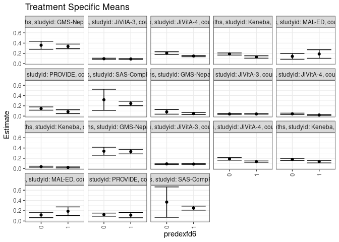

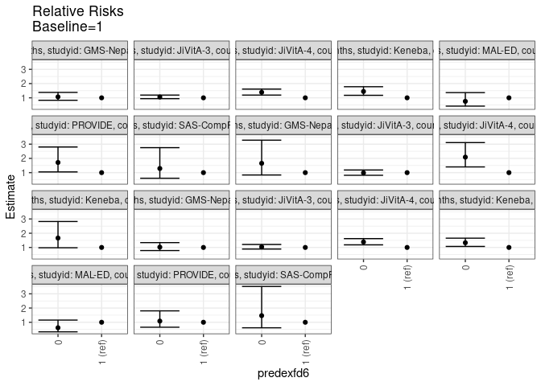

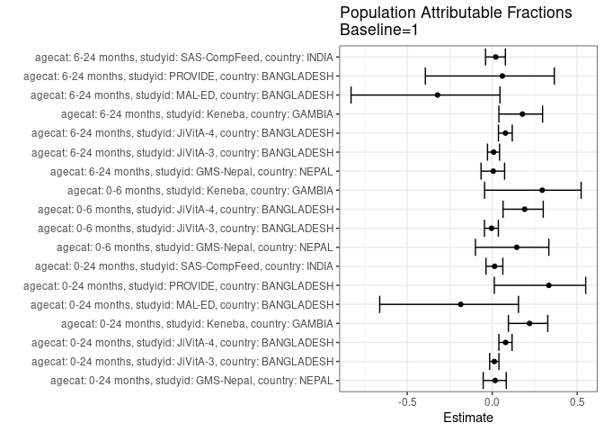

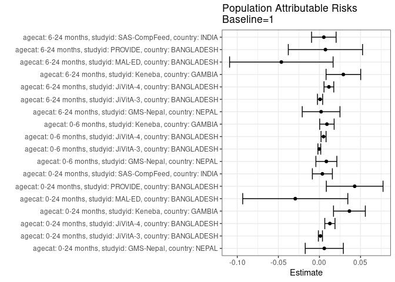

## Results Table

### Parameter: TSM

| agecat | studyid | country | intervention_level | baseline_level | estimate | ci_lower | ci_upper |
| --- | --- | --- | --- | --- | --- | --- | --- |
| 0-24 months | GMS-Nepal | NEPAL | 1 | NA | 0.3357143 | 0.2905109 | 0.3809176 |
| 0-24 months | GMS-Nepal | NEPAL | 0 | NA | 0.3586207 | 0.2804896 | 0.4367518 |
| 0-24 months | JiVitA-3 | BANGLADESH | 1 | NA | 0.0903959 | 0.0848875 | 0.0959043 |
| 0-24 months | JiVitA-3 | BANGLADESH | 0 | NA | 0.0956869 | 0.0857322 | 0.1056417 |
| 0-24 months | JiVitA-4 | BANGLADESH | 1 | NA | 0.1482582 | 0.1352166 | 0.1612997 |
| 0-24 months | JiVitA-4 | BANGLADESH | 0 | NA | 0.2057143 | 0.1799964 | 0.2314321 |
| 0-24 months | Keneba | GAMBIA | 1 | NA | 0.1295400 | 0.1066349 | 0.1524450 |
| 0-24 months | Keneba | GAMBIA | 0 | NA | 0.1873669 | 0.1669879 | 0.2077460 |
| 0-24 months | MAL-ED | BANGLADESH | 1 | NA | 0.1882353 | 0.1049558 | 0.2715148 |
| 0-24 months | MAL-ED | BANGLADESH | 0 | NA | 0.1418919 | 0.0855539 | 0.1982298 |
| 0-24 months | PROVIDE | BANGLADESH | 1 | NA | 0.0857143 | 0.0478250 | 0.1236036 |
| 0-24 months | PROVIDE | BANGLADESH | 0 | NA | 0.1469388 | 0.1155685 | 0.1783091 |
| 0-24 months | SAS-CompFeed | INDIA | 1 | NA | 0.2464455 | 0.2022875 | 0.2906035 |
| 0-24 months | SAS-CompFeed | INDIA | 0 | NA | 0.3181818 | 0.1124254 | 0.5239382 |
| 0-6 months | GMS-Nepal | NEPAL | 1 | NA | 0.0500000 | 0.0291380 | 0.0708620 |
| 0-6 months | GMS-Nepal | NEPAL | 0 | NA | 0.0827586 | 0.0378740 | 0.1276432 |
| 0-6 months | JiVitA-3 | BANGLADESH | 1 | NA | 0.0419292 | 0.0380420 | 0.0458165 |
| 0-6 months | JiVitA-3 | BANGLADESH | 0 | NA | 0.0412017 | 0.0345392 | 0.0478642 |
| 0-6 months | JiVitA-4 | BANGLADESH | 1 | NA | 0.0211669 | 0.0152954 | 0.0270384 |
| 0-6 months | JiVitA-4 | BANGLADESH | 0 | NA | 0.0442043 | 0.0312540 | 0.0571547 |
| 0-6 months | Keneba | GAMBIA | 1 | NA | 0.0217918 | 0.0118327 | 0.0317508 |
| 0-6 months | Keneba | GAMBIA | 0 | NA | 0.0361959 | 0.0264412 | 0.0459506 |
| 6-24 months | GMS-Nepal | NEPAL | 1 | NA | 0.3301205 | 0.2848361 | 0.3754049 |
| 6-24 months | GMS-Nepal | NEPAL | 0 | NA | 0.3380282 | 0.2601546 | 0.4159018 |
| 6-24 months | JiVitA-3 | BANGLADESH | 1 | NA | 0.0874587 | 0.0807870 | 0.0941305 |
| 6-24 months | JiVitA-3 | BANGLADESH | 0 | NA | 0.0907519 | 0.0781373 | 0.1033666 |
| 6-24 months | JiVitA-4 | BANGLADESH | 1 | NA | 0.1353180 | 0.1231193 | 0.1475167 |
| 6-24 months | JiVitA-4 | BANGLADESH | 0 | NA | 0.1873805 | 0.1630535 | 0.2117075 |
| 6-24 months | Keneba | GAMBIA | 1 | NA | 0.1345354 | 0.1096223 | 0.1594484 |
| 6-24 months | Keneba | GAMBIA | 0 | NA | 0.1789627 | 0.1586526 | 0.1992729 |
| 6-24 months | MAL-ED | BANGLADESH | 1 | NA | 0.1904762 | 0.1063185 | 0.2746339 |
| 6-24 months | MAL-ED | BANGLADESH | 0 | NA | 0.1172414 | 0.0647636 | 0.1697192 |
| 6-24 months | PROVIDE | BANGLADESH | 1 | NA | 0.1148649 | 0.0634523 | 0.1662775 |
| 6-24 months | PROVIDE | BANGLADESH | 0 | NA | 0.1244635 | 0.0944673 | 0.1544598 |
| 6-24 months | SAS-CompFeed | INDIA | 1 | NA | 0.2512563 | 0.2120897 | 0.2904228 |
| 6-24 months | SAS-CompFeed | INDIA | 0 | NA | 0.3684211 | 0.0727072 | 0.6641349 |

### Parameter: E(Y)

| agecat | studyid | country | intervention_level | baseline_level | estimate | ci_lower | ci_upper |
| --- | --- | --- | --- | --- | --- | --- | --- |
| 0-24 months | GMS-Nepal | NEPAL | NA | NA | 0.3415929 | 0.3024539 | 0.3807320 |
| 0-24 months | JiVitA-3 | BANGLADESH | NA | NA | 0.0915608 | 0.0867079 | 0.0964137 |
| 0-24 months | JiVitA-4 | BANGLADESH | NA | NA | 0.1609510 | 0.1491579 | 0.1727440 |
| 0-24 months | Keneba | GAMBIA | NA | NA | 0.1659955 | 0.1505665 | 0.1814246 |
| 0-24 months | MAL-ED | BANGLADESH | NA | NA | 0.1587983 | 0.1117681 | 0.2058285 |
| 0-24 months | PROVIDE | BANGLADESH | NA | NA | 0.1285714 | 0.1037574 | 0.1533855 |
| 0-24 months | SAS-CompFeed | INDIA | NA | NA | 0.2500000 | 0.2118239 | 0.2881761 |
| 0-6 months | GMS-Nepal | NEPAL | NA | NA | 0.0584071 | 0.0390530 | 0.0777612 |
| 0-6 months | JiVitA-3 | BANGLADESH | NA | NA | 0.0417690 | 0.0384207 | 0.0451174 |
| 0-6 months | JiVitA-4 | BANGLADESH | NA | NA | 0.0261535 | 0.0207066 | 0.0316005 |
| 0-6 months | Keneba | GAMBIA | NA | NA | 0.0308725 | 0.0236998 | 0.0380452 |
| 6-24 months | GMS-Nepal | NEPAL | NA | NA | 0.3321364 | 0.2929882 | 0.3712847 |
| 6-24 months | JiVitA-3 | BANGLADESH | NA | NA | 0.0882064 | 0.0821266 | 0.0942862 |
| 6-24 months | JiVitA-4 | BANGLADESH | NA | NA | 0.1468045 | 0.1358635 | 0.1577455 |
| 6-24 months | Keneba | GAMBIA | NA | NA | 0.1636364 | 0.1477722 | 0.1795005 |
| 6-24 months | MAL-ED | BANGLADESH | NA | NA | 0.1441048 | 0.0985189 | 0.1896907 |
| 6-24 months | PROVIDE | BANGLADESH | NA | NA | 0.1221498 | 0.0962275 | 0.1480722 |
| 6-24 months | SAS-CompFeed | INDIA | NA | NA | 0.2565947 | 0.2209578 | 0.2922316 |

### Parameter: RR

| agecat | studyid | country | intervention_level | baseline_level | estimate | ci_lower | ci_upper |
| --- | --- | --- | --- | --- | --- | --- | --- |
| 0-24 months | GMS-Nepal | NEPAL | 1 | 1 | 1.0000000 | 1.0000000 | 1.000000 |
| 0-24 months | GMS-Nepal | NEPAL | 0 | 1 | 1.0682318 | 0.8268670 | 1.380052 |
| 0-24 months | JiVitA-3 | BANGLADESH | 1 | 1 | 1.0000000 | 1.0000000 | 1.000000 |
| 0-24 months | JiVitA-3 | BANGLADESH | 0 | 1 | 1.0585315 | 0.9391051 | 1.193145 |
| 0-24 months | JiVitA-4 | BANGLADESH | 1 | 1 | 1.0000000 | 1.0000000 | 1.000000 |
| 0-24 months | JiVitA-4 | BANGLADESH | 0 | 1 | 1.3875410 | 1.1937092 | 1.612847 |
| 0-24 months | Keneba | GAMBIA | 1 | 1 | 1.0000000 | 1.0000000 | 1.000000 |
| 0-24 months | Keneba | GAMBIA | 0 | 1 | 1.4464026 | 1.1752571 | 1.780105 |
| 0-24 months | MAL-ED | BANGLADESH | 1 | 1 | 1.0000000 | 1.0000000 | 1.000000 |
| 0-24 months | MAL-ED | BANGLADESH | 0 | 1 | 0.7538007 | 0.4159920 | 1.365929 |
| 0-24 months | PROVIDE | BANGLADESH | 1 | 1 | 1.0000000 | 1.0000000 | 1.000000 |
| 0-24 months | PROVIDE | BANGLADESH | 0 | 1 | 1.7142857 | 1.0492751 | 2.800768 |
| 0-24 months | SAS-CompFeed | INDIA | 1 | 1 | 1.0000000 | 1.0000000 | 1.000000 |
| 0-24 months | SAS-CompFeed | INDIA | 0 | 1 | 1.2910839 | 0.6050646 | 2.754908 |
| 0-6 months | GMS-Nepal | NEPAL | 1 | 1 | 1.0000000 | 1.0000000 | 1.000000 |
| 0-6 months | GMS-Nepal | NEPAL | 0 | 1 | 1.6551724 | 0.8349580 | 3.281118 |
| 0-6 months | JiVitA-3 | BANGLADESH | 1 | 1 | 1.0000000 | 1.0000000 | 1.000000 |
| 0-6 months | JiVitA-3 | BANGLADESH | 0 | 1 | 0.9826490 | 0.8145856 | 1.185387 |
| 0-6 months | JiVitA-4 | BANGLADESH | 1 | 1 | 1.0000000 | 1.0000000 | 1.000000 |
| 0-6 months | JiVitA-4 | BANGLADESH | 0 | 1 | 2.0883709 | 1.4012961 | 3.112328 |
| 0-6 months | Keneba | GAMBIA | 1 | 1 | 1.0000000 | 1.0000000 | 1.000000 |
| 0-6 months | Keneba | GAMBIA | 0 | 1 | 1.6609889 | 0.9771263 | 2.823467 |
| 6-24 months | GMS-Nepal | NEPAL | 1 | 1 | 1.0000000 | 1.0000000 | 1.000000 |
| 6-24 months | GMS-Nepal | NEPAL | 0 | 1 | 1.0239539 | 0.7831336 | 1.338829 |
| 6-24 months | JiVitA-3 | BANGLADESH | 1 | 1 | 1.0000000 | 1.0000000 | 1.000000 |
| 6-24 months | JiVitA-3 | BANGLADESH | 0 | 1 | 1.0376543 | 0.8899650 | 1.209853 |
| 6-24 months | JiVitA-4 | BANGLADESH | 1 | 1 | 1.0000000 | 1.0000000 | 1.000000 |
| 6-24 months | JiVitA-4 | BANGLADESH | 0 | 1 | 1.3847419 | 1.1829716 | 1.620926 |
| 6-24 months | Keneba | GAMBIA | 1 | 1 | 1.0000000 | 1.0000000 | 1.000000 |
| 6-24 months | Keneba | GAMBIA | 0 | 1 | 1.3302282 | 1.0705392 | 1.652912 |
| 6-24 months | MAL-ED | BANGLADESH | 1 | 1 | 1.0000000 | 1.0000000 | 1.000000 |
| 6-24 months | MAL-ED | BANGLADESH | 0 | 1 | 0.6155172 | 0.3281680 | 1.154474 |
| 6-24 months | PROVIDE | BANGLADESH | 1 | 1 | 1.0000000 | 1.0000000 | 1.000000 |
| 6-24 months | PROVIDE | BANGLADESH | 0 | 1 | 1.0835648 | 0.6517490 | 1.801480 |
| 6-24 months | SAS-CompFeed | INDIA | 1 | 1 | 1.0000000 | 1.0000000 | 1.000000 |
| 6-24 months | SAS-CompFeed | INDIA | 0 | 1 | 1.4663158 | 0.6118309 | 3.514177 |

### Parameter: PAR

| agecat | studyid | country | intervention_level | baseline_level | estimate | ci_lower | ci_upper |
| --- | --- | --- | --- | --- | --- | --- | --- |
| 0-24 months | GMS-Nepal | NEPAL | 1 | NA | 0.0058786 | -0.0173015 | 0.0290588 |
| 0-24 months | JiVitA-3 | BANGLADESH | 1 | NA | 0.0011649 | -0.0013249 | 0.0036547 |
| 0-24 months | JiVitA-4 | BANGLADESH | 1 | NA | 0.0126928 | 0.0064853 | 0.0189004 |
| 0-24 months | Keneba | GAMBIA | 1 | NA | 0.0364556 | 0.0170930 | 0.0558181 |
| 0-24 months | MAL-ED | BANGLADESH | 1 | NA | -0.0294370 | -0.0933674 | 0.0344934 |
| 0-24 months | PROVIDE | BANGLADESH | 1 | NA | 0.0428571 | 0.0083611 | 0.0773532 |
| 0-24 months | SAS-CompFeed | INDIA | 1 | NA | 0.0035545 | -0.0086130 | 0.0157220 |
| 0-6 months | GMS-Nepal | NEPAL | 1 | NA | 0.0084071 | -0.0043502 | 0.0211643 |
| 0-6 months | JiVitA-3 | BANGLADESH | 1 | NA | -0.0001602 | -0.0018694 | 0.0015491 |
| 0-6 months | JiVitA-4 | BANGLADESH | 1 | NA | 0.0049866 | 0.0019446 | 0.0080287 |
| 0-6 months | Keneba | GAMBIA | 1 | NA | 0.0090807 | 0.0002876 | 0.0178739 |
| 6-24 months | GMS-Nepal | NEPAL | 1 | NA | 0.0020160 | -0.0209514 | 0.0249833 |
| 6-24 months | JiVitA-3 | BANGLADESH | 1 | NA | 0.0007477 | -0.0023917 | 0.0038870 |
| 6-24 months | JiVitA-4 | BANGLADESH | 1 | NA | 0.0114865 | 0.0055563 | 0.0174167 |
| 6-24 months | Keneba | GAMBIA | 1 | NA | 0.0291010 | 0.0080272 | 0.0501748 |
| 6-24 months | MAL-ED | BANGLADESH | 1 | NA | -0.0463714 | -0.1093371 | 0.0165943 |
| 6-24 months | PROVIDE | BANGLADESH | 1 | NA | 0.0072850 | -0.0378919 | 0.0524619 |
| 6-24 months | SAS-CompFeed | INDIA | 1 | NA | 0.0053384 | -0.0095993 | 0.0202761 |

### Parameter: PAF

| agecat | studyid | country | intervention_level | baseline_level | estimate | ci_lower | ci_upper |
| --- | --- | --- | --- | --- | --- | --- | --- |
| 0-24 months | GMS-Nepal | NEPAL | 1 | NA | 0.0172095 | -0.0530476 | 0.0827792 |
| 0-24 months | JiVitA-3 | BANGLADESH | 1 | NA | 0.0127224 | -0.0148740 | 0.0395685 |
| 0-24 months | JiVitA-4 | BANGLADESH | 1 | NA | 0.0788613 | 0.0393333 | 0.1167630 |
| 0-24 months | Keneba | GAMBIA | 1 | NA | 0.2196178 | 0.0952405 | 0.3268970 |
| 0-24 months | MAL-ED | BANGLADESH | 1 | NA | -0.1853736 | -0.6618630 | 0.1544967 |
| 0-24 months | PROVIDE | BANGLADESH | 1 | NA | 0.3333333 | 0.0123377 | 0.5500036 |
| 0-24 months | SAS-CompFeed | INDIA | 1 | NA | 0.0142180 | -0.0365627 | 0.0625110 |
| 0-6 months | GMS-Nepal | NEPAL | 1 | NA | 0.1439394 | -0.0988175 | 0.3330651 |
| 0-6 months | JiVitA-3 | BANGLADESH | 1 | NA | -0.0038351 | -0.0455757 | 0.0362392 |
| 0-6 months | JiVitA-4 | BANGLADESH | 1 | NA | 0.1906675 | 0.0639161 | 0.3002560 |
| 0-6 months | Keneba | GAMBIA | 1 | NA | 0.2941362 | -0.0449047 | 0.5231683 |
| 6-24 months | GMS-Nepal | NEPAL | 1 | NA | 0.0060697 | -0.0655428 | 0.0728693 |
| 6-24 months | JiVitA-3 | BANGLADESH | 1 | NA | 0.0084766 | -0.0277292 | 0.0434069 |
| 6-24 months | JiVitA-4 | BANGLADESH | 1 | NA | 0.0782434 | 0.0367951 | 0.1179080 |
| 6-24 months | Keneba | GAMBIA | 1 | NA | 0.1778394 | 0.0393385 | 0.2963723 |
| 6-24 months | MAL-ED | BANGLADESH | 1 | NA | -0.3217893 | -0.8304107 | 0.0455000 |
| 6-24 months | PROVIDE | BANGLADESH | 1 | NA | 0.0596396 | -0.3932546 | 0.3653152 |
| 6-24 months | SAS-CompFeed | INDIA | 1 | NA | 0.0208050 | -0.0393691 | 0.0774953 |